# Health Risk Analysis

# ——————————————————————————

# I EMPLOYED THE USE OF A SCATTERPLOT TO SHOW AGE VS CHOLESTEROL

# ——————————————————————————

scatter_plot <- ggplot( healthcare_data, aes( x = age, y = cholesterol, color = age ) ) + geom_point( size = 3, alpha = 0.7 ) + scale_color_gradient( low = “blue”, high = “red” ) + labs( title = “Age vs Cholesterol”, x = “Age”, y = “Cholesterol Level” ) + theme_minimal()

#print(scatter_plot)

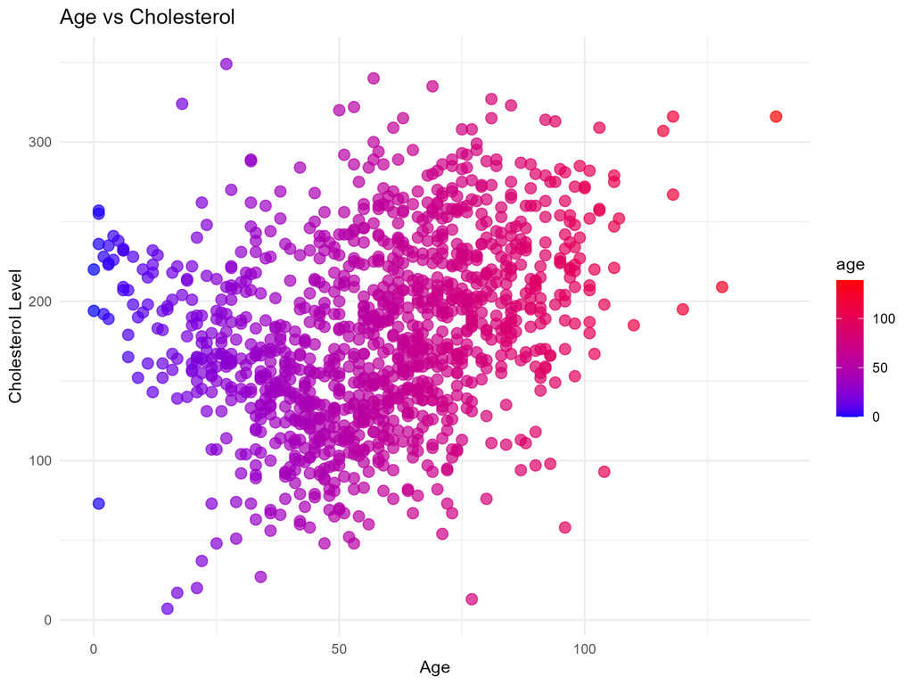

#====================================================== # I Saved the figure in file name given below ggsave( filename = “outputs/figures/age_vs_cholesterol.png”, plot = scatter_plot, width = 8, height = 6, dpi = 300 ) #=====================================================

# —————————————————–

# I DECIDED TO SHOW VARIABLE CORRELATION ON HEATMAP

# —————————————————–

# Here I generated a correlation matrix

correlation_matrix <- cor( healthcare_data )

# Then I had to Convert matrix to long format by melting the Matrix

melted_correlation <- melt( correlation_matrix )

# I then Created a heatmap

correlation_heatmap <- ggplot( melted_correlation, aes( x = Var1, y = Var2, fill = value ) ) + geom_tile() + scale_fill_gradient2( low = “blue”, mid = “white”, high = “red”, midpoint = 0 ) + labs( title = “Correlation Heatmap” ) + theme_minimal() + theme( axis.text.x = element_text( angle = 45, hjust = 1 ) ) #This printout the heatmap #print(correlation_heatmap)

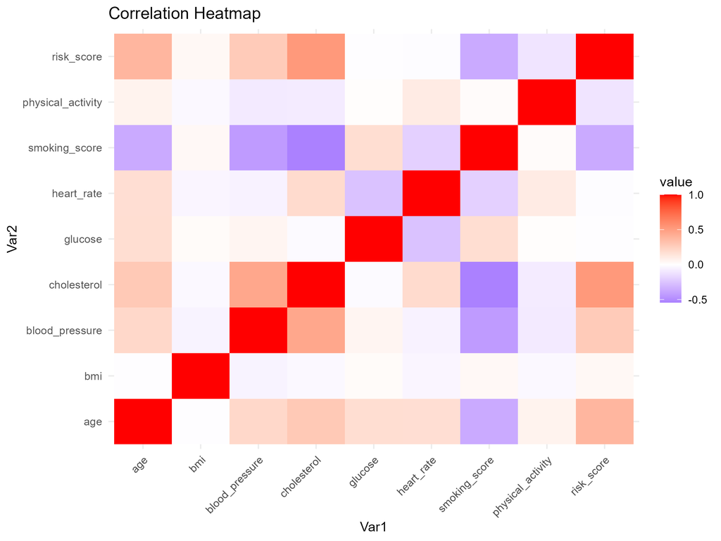

#==================================================== # I Saved the heat map in the outputs ,figures folder ggsave( filename = “outputs/figures/correlation_heatmap.png”, plot = correlation_heatmap, width = 8, height = 6, dpi = 300 ) #====================================================

# —————————————————–

# I SHOWED BMI IN A BOXPLOT BY RISK SCORE

# —————————————————–

bmi_boxplot <- ggplot( healthcare_data, aes( x = as.factor(risk_score), y = bmi, fill = as.factor(risk_score) ) ) + geom_boxplot() + scale_fill_manual( values = c(“skyblue”, “tomato”) ) + labs( title = “BMI Distribution by Risk Score”, x = “Risk Score”, y = “BMI” ) + theme_minimal()

#print(bmi_boxplot)

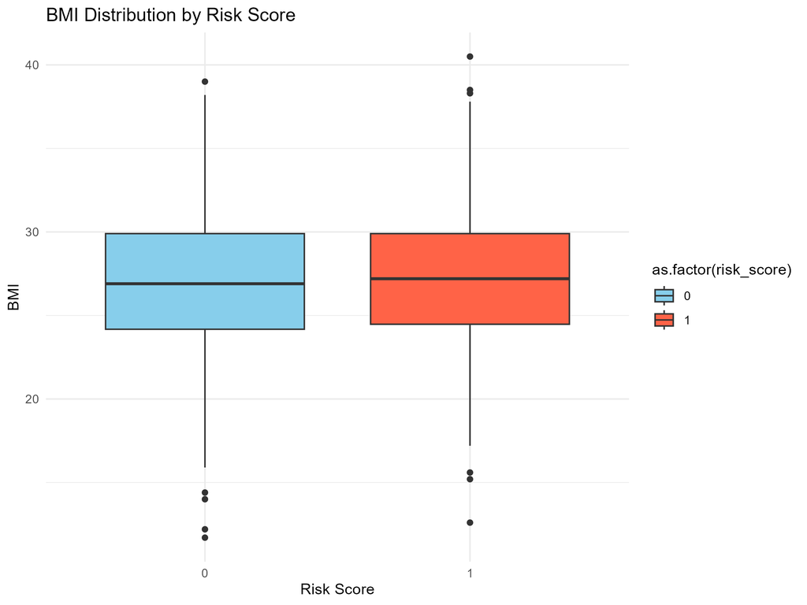

# I save this in the same folder as other outputs

ggsave( filename = “outputs/figures/bmi_boxplot.png”, plot = bmi_boxplot, width = 8, height = 6, dpi = 300 )

# —————————————————–

# HERE I CHECKED THE BMI BY RISK GROUP ON A HISTOGRAM

# —————————————————–

risk_histogram <- ggplot( healthcare_data, aes( x = bmi, fill = as.factor(risk_score) ) ) + geom_histogram( bins = 30, alpha = 0.7, position = “identity” ) + scale_fill_manual( values = c(“cyan”, “magenta”) ) + labs( title = “BMI Histogram by Risk Group”, x = “BMI”, y = “Frequency” ) + theme_minimal()

#print(risk_histogram)

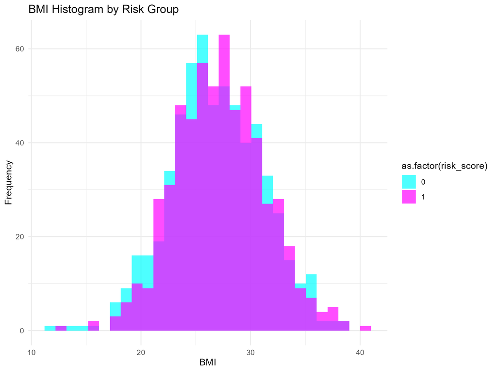

#———————————————————— # I saved this in the same folder as other outputs ggsave( filename = “outputs/figures/risk_histogram.png”, plot = risk_histogram, width = 8, height = 6, dpi = 300 )

# =====================================================

# I USED PCA FOR DATA VISUALIZATIONS

# =====================================================

# I first Converted the target variable to factor which is the risk_score

healthcare_data$risk_score <- as.factor( healthcare_data$risk_score )

# I presented this in a Scree Plot visualisation to capture the variance

scree_plot <- fviz_eig( pca_results, addlabels = TRUE, barfill = “steelblue”, barcolor = “black” ) + ggtitle( “Scree Plot - Explained Variance” )

#print(scree_plot)

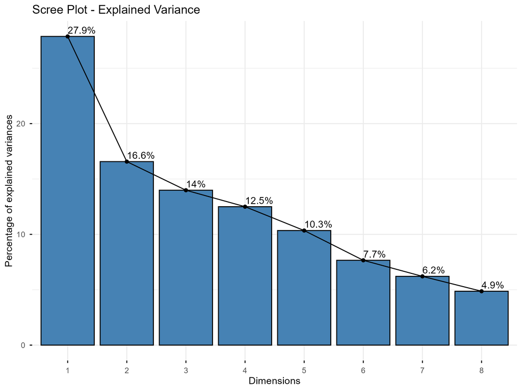

#I Saved the scree plot in the link below with other figures ggsave( filename = “outputs/figures/scree_plot.png”, plot = scree_plot, width = 8, height = 6, dpi = 300 )

# —————————————————–

# —————————————————–

pca_individual_plot <- fviz_pca_ind( pca_results, geom.ind = “point”, habillage = healthcare_data$risk_score, palette = c(“blue”, “red”), addEllipses = TRUE )

#print(pca_individual_plot)

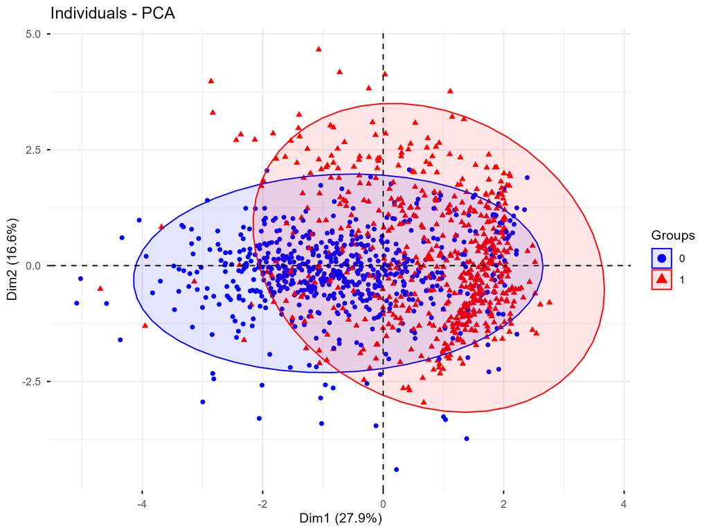

# Saved PCA individuals plot in the outputs/figures folder

ggsave( filename = “outputs/figures/pca_individual_plot.png”, plot = pca_individual_plot, width = 8, height = 6, dpi = 300 )

# =====================================================

# LASTLY I SAVED ALL OTHER REPORTS OUTPUTS IN THE REPORTS FOLDER PATH

#Regression summary,Confusion matrix,PCA eigenvalues # =====================================================

# I Saved regression summary

sink( “outputs/reports/linear_regression_summary.txt” )

summary(linear_model)

sink()

# I Saved confusion matrix

capture.output( confusion_matrix, file = “outputs/reports/confusion_matrix.txt” )

# Save PCA eigenvalues

write.csv( pca_results$eig, “outputs/reports/pca_eigenvalues.csv” )

# =====================================================

# =====================================================

R.version.string sessionInfo()